# RL RNA dataset UCI

Importamos librerías requeridas

Ahora importamos el dataset e imprimimos una vista previa.

```r
datasetUCI <- read.csv("./heart.csv")
head(datasetUCI)
```

Verificamos si hay datos nulos…

```r
sum(is.na(datasetUCI))
str(datasetUCI)
```

Necesitamos etiquetar nuestras variables para poder trabajar mejor con ellas

```r
#Etiquetando los features

#Target
datasetUCI$target<-as.factor(datasetUCI$target)
levels(datasetUCI$target)[levels(datasetUCI$target)==0] <- "No Enfermo"
levels(datasetUCI$target)[levels(datasetUCI$target)==1] <- "Enfermo"
#Dolor en Pecho

datasetUCI$cp<-as.factor(datasetUCI$cp)
levels(datasetUCI$cp)[levels(datasetUCI$cp)==0] <- "Dolor En Pecho Tipo 0"
levels(datasetUCI$cp)[levels(datasetUCI$cp)==1] <- "Dolor En Pecho Tipo 1"
levels(datasetUCI$cp)[levels(datasetUCI$cp)==2] <- "Dolor En Pecho Tipo 2"
levels(datasetUCI$cp)[levels(datasetUCI$cp)==3] <- "Dolor En Pecho Tipo 3"

#Sexo
datasetUCI$sex<-as.factor(datasetUCI$sex)
levels(datasetUCI$sex)[levels(datasetUCI$sex)==0] <- "Femenino"
levels(datasetUCI$sex)[levels(datasetUCI$sex)==1] <- "Masculino"

#Talasemia
datasetUCI$thal<-as.factor(datasetUCI$thal)
levels(datasetUCI$thal)[levels(datasetUCI$thal)==0] <- "Sin Talasemia"
levels(datasetUCI$thal)[levels(datasetUCI$thal)==1] <- "Talasemia Normal"
levels(datasetUCI$thal)[levels(datasetUCI$thal)==2] <- "Talasemia - Defecto Reparado"
levels(datasetUCI$thal)[levels(datasetUCI$thal)==3] <- "Talasemia - Defecto Reversible"

#Azúcar en la sangre, en ayunas
datasetUCI$fbs<-as.factor(datasetUCI$fbs)
levels(datasetUCI$fbs)[levels(datasetUCI$fbs)==0] <- "Azúcar en Sangre, en Ayunas <= 120"
levels(datasetUCI$fbs)[levels(datasetUCI$fbs)==1] <- "Azúcar en Sangre, en Ayunas > 120"

#Angina Inducida por Ejercicio
datasetUCI$exang<-as.factor(datasetUCI$exang)
levels(datasetUCI$exang)[levels(datasetUCI$exang)==0] <- "Sin Angina Inducida por Ejercicio"
levels(datasetUCI$exang)[levels(datasetUCI$exang)==1] <- "Angina Inducida por Ejercicio"

#ECG
datasetUCI$restecg<-as.factor(datasetUCI$restecg)
levels(datasetUCI$restecg)[levels(datasetUCI$restecg)==0] <- "ECG en Reposo 0"
levels(datasetUCI$restecg)[levels(datasetUCI$restecg)==1] <- "ECG en Reposo 1"
levels(datasetUCI$restecg)[levels(datasetUCI$restecg)==2] <- "ECG en Reposo 2"

#ST Slope
datasetUCI$slope<-as.factor(datasetUCI$slope)
levels(datasetUCI$slope)[levels(datasetUCI$slope)==0] <- "Pendiente Tope Segmento ST durante Ejercicio 0"
levels(datasetUCI$slope)[levels(datasetUCI$slope)==1] <- "Pendiente Tope Segmento ST durante Ejercicio 1"
levels(datasetUCI$slope)[levels(datasetUCI$slope)==2] <- "Pendiente Tope Segmento ST durante Ejercicio 2"
```

```r
str(datasetUCI)
summary(datasetUCI)
```

Total observaciones gente enferma vs gente no enferma

```r
ggplot(datasetUCI,aes(target, fill=target)) +
geom_bar(stat="count") + theme_clean() +
scale_fill_manual(values=c("#97BE11","#DC1E0B"))
ggsave("UCI-total-obs.png")
```

Enfermedad cardíaca más prominente entre mujeres que entre hombres.

```r
ggplot(datasetUCI,aes(target, fill=target)) +
geom_bar(stat="count") +
facet_wrap(~sex, ncol=2,scale="fixed") +
theme_clean() +
scale_fill_manual(values=c("#97BE11","#DC1E0B"))
ggsave("UCI-target-vs-sex.png")
```

```r
ggplot(datasetUCI,aes(trestbps, fill=target)) +
geom_histogram(aes(y=..density..),breaks=seq(90, 200, by=10), color="grey17") +
geom_density(alpha=.1, fill="black") +
facet_wrap(~target, ncol=1,scale="fixed") +
theme_clean() +
scale_fill_manual(values=c("#97BE11","#DC1E0B")) +
xlab("Presión Sanguínea en Reposo (en momento de ingreso a hospital) (mmHg)") +
ylab("Densidad / Conteo") +
ggtitle("Histograma - ECG en reposo")
ggsave("UCI-hist-restECG.png")
```

```r
ggplot(datasetUCI,aes(age, fill=target)) +
geom_histogram(aes(y=..density..),breaks=seq(0, 80, by=1), color="grey17") +
geom_density(alpha=.1, fill="black")+ facet_wrap(~target, ncol=1,scale="fixed") +
theme_clean() + scale_fill_manual(values=c("#97BE11","#DC1E0B"))+ xlab("Edad") +
ylab("Densidad / Conteo") +
ggtitle("Histograma - Edad")
ggsave("UCI-hist-edad.png")
```

```r
ggplot(datasetUCI,aes(x=target, y=age, fill=target)) +
geom_boxplot() +
theme_clean() +
scale_fill_manual(values=c("#97BE11","#DC1E0B"))
ggsave("UCI-boxplot-edad.png")
```

```r
ggplot(datasetUCI,aes(thalach, fill=target)) +
geom_histogram(aes(y=..density..),breaks=seq(70, 205, by=10), color="grey17") +
geom_density(alpha=.1, fill="black") +
facet_wrap(~target, ncol=1,scale="fixed") +
theme_clean() +
scale_fill_manual(values=c("#97BE11","#DC1E0B")) +
xlab("Máximo Ritmo Cardíaco") +
ylab("Densidad / Conteo") +
ggtitle("Histograma - Máximo Ritmo Cardíaco")
ggsave("UCI-hist-max-heart.png")
```

Se puede evidenciar que la gente con enfermedades cardíacas generalmente tienen ritmos cardíacos más altos.

```r
ggplot(datasetUCI,aes(chol, fill=target)) +
geom_histogram(aes(y=..density..),breaks=seq(100, 600, by=25), color="grey17") +
geom_density(alpha=.1, fill="black") +
facet_wrap(~target, ncol=1,scale="fixed") +
theme_clean() +
scale_fill_manual(values=c("#97BE11","#DC1E0B")) +
xlab("Colesterol Total en mg/dL") +
ylab("Densidad / Conteo") +
ggtitle("Histograma - Colesterol Total")
ggsave("UCI-hist-colest.png")
```

```r
ggplot(datasetUCI,aes(oldpeak, fill=target)) +
geom_histogram(aes(y=..density..),breaks=seq(0, 7, by=0.1), color="grey17") +
geom_density(alpha=.1, fill="black") +
facet_wrap(~target, ncol=1,scale="fixed") +
theme_clean() +
scale_fill_manual(values=c("#97BE11","#DC1E0B")) +
ggtitle("Histograma - Depresión en Segmento ST") +
xlab("Depresión en Segmento ST Inducida por Ejercicio") +
ylab("Densidad / Counteo")
ggsave("UCI-hist-dep-ST.png")
```

La mayoría de pacientes enfermos tienen depresión en segmento ST de 0.1.

```r
ggplot(datasetUCI,aes(ca, fill=target)) +
geom_histogram(aes(y=..density..),breaks=seq(0, 5, by=1), color="grey17") +
geom_density(alpha=.1, fill="black") +
facet_wrap(~target, ncol=1,scale="fixed") +
theme_clean() +
scale_fill_manual(values=c("#97BE11","#DC1E0B")) +
ggtitle("Histograma - N° vasos sanguíneos coloreados") +
xlab("N° de vasos sanguíneos importantes coloreados (0-3) durante fluoroscopía") +
ylab("Densidad / Conteo")
ggsave("UCI-num-vasos-col.png")
```

La mayoría de personas sin vasos sanguíneos coloreados durante una fluoroscopía sufren de enfermedad cardíaca.

```r
ggplot(datasetUCI,aes(target, fill=target)) +
geom_bar(stat="count") +
facet_wrap(~cp, ncol=2,scale="fixed") +
theme_clean() +
scale_fill_manual(values=c("#97BE11","#DC1E0B"))
ggsave("UCI-dolor-pecho.png")
```

Mayoría de personas enfermas sufren de dolor en pecho tipo 1 o tipo 2.

```r
ggplot(datasetUCI,aes(target, fill=target)) +
geom_bar(stat="count") +
facet_wrap(~fbs, ncol=2,scale="fixed") +
theme_clean() +
scale_fill_manual(values=c("#97BE11","#DC1E0B"))
ggsave("UCI-azucar-sangre.png")
```

No hay diferencia significativa en azúcar en la sangre estando en ayunas .

```r
ggplot(datasetUCI,aes(target, fill=target)) +
geom_bar(stat="count") +
facet_wrap(~restecg, ncol=3,scale="fixed") +
theme_clean() +
scale_fill_manual(values=c("#97BE11","#DC1E0B"))
ggsave("UCI-ECG-reposo.png")
```

Personas con resultado 1 en el ECG en reposo tienen probabilidad más alta de enfermedad cardíaca.

```r
ggplot(datasetUCI,aes(target, fill=target)) +
geom_bar(stat="count") +
facet_wrap(~exang, ncol=1,scale="fixed") +
theme_clean() +
scale_fill_manual(values=c("#97BE11","#DC1E0B"))
ggsave("UCI-exang.png")
```

Personas sin angina inducida por ejercicio tienen probabilidad más alta de enfermedad cardíaca.

```r
ggplot(datasetUCI,aes(target, fill=target)) +
geom_bar(stat="count") +
facet_wrap(~slope, ncol=1,scale="fixed") +
theme_clean() +
scale_fill_manual(values=c("#97BE11","#DC1E0B"))
ggsave("UCI-ST-slope.png")
```

Personas con Pendiente 2 tienen probabilidad más alta de enfermedad cardíaca.

```r
ggplot(datasetUCI,aes(target, fill=target)) +
geom_bar(stat="count") +
facet_wrap(~thal, ncol=2,scale="fixed") +
theme_clean() +
scale_fill_manual(values=c("#97BE11","#DC1E0B"))
ggsave("UCI-thal.png")
```

Personas con Talasemia (defecto reparado) tienen probabilidad más alta de enfermedad cardíaca.

```r
log<-glm(target~., data=datasetUCI, family=binomial)
summary(log)
```

Se conservan sólo las variables significativas, gracias al análisis anterior del modelo lineal generalizado.

```r
d<-datasetUCI[,c(2,3,9,10,12,14)]
summary(d)
```

Modelo lineal generalizado con las variables que conversamos.

```r
log<-glm(target~., data=d, family=binomial)
summary(log)
```

```r
log.df<-tidy(log)
```

Observaciones muestran que con dolor en pecho tipo 2 o 3, hay mayor probabilidad de enfermedad cardíaca. La probabilidad disminuye si el paciente es hombre, presenta angina inducida por el ejercicio y/o presenta más vasos sanguíneos coloreados durante fluoroscopía.

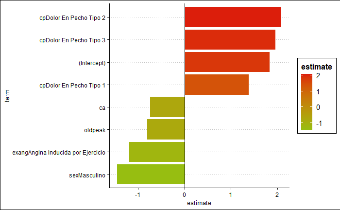

```r
log.df %>%
mutate(term=reorder(term,estimate)) %>%
ggplot( aes(term,estimate, fill=estimate)) +
geom_bar(stat="identity") +
scale_fill_gradient(low = "#97BE11",high = "#DC1E0B") +
theme_clean() +
geom_hline(yintercept=0) +
coord_flip()
ggsave("UCI-ord-var-imp-est.png")
```

```r
data<-d
set.seed(1237)
train <- sample(nrow(data), .8*nrow(data), replace = FALSE)
TrainingSet <- data[train,]
ValidSet <- data[-train,]

fitControl <- trainControl(method = "repeatedcv",
                            number = 10,
                            repeats = 10,
                            classProbs = TRUE,
                            summaryFunction = twoClassSummary)

TrainingSet$target<-make.names(TrainingSet$target)
set.seed(142)
TrainingSet$target<-as.factor(TrainingSet$target)
gbm.ada.1 <- caret::train(target ~ .,
                            data = TrainingSet ,
                            method = "glm",
                            trControl = fitControl,
                            metric="ROC")

gbm.ada.1
```

```
Generalized Linear Model

820 samples
  5 predictor
  2 classes: 'Enfermo', 'No.Enfermo'

No pre-processing
Resampling: Cross-Validated (10 fold, repeated 10 times)
Summary of sample sizes: 738, 739, 738, 738, 738, 738, ...
Resampling results:

  ROC        Sens       Spec
  0.8904466  0.8524751  0.7903141
```

```r
varImp(gbm.ada.1)
```

```
glm variable importance
```

|  | Overall |
| --- | --- |
| `cpDolor En Pecho Tipo 2` | 100.00000 |
| oldpeak | 78.85428 |
| ca | 68.24241 |
| sexMasculino | 41.78509 |
| `cpDolor En Pecho Tipo 3` | 19.79727 |
| `exangAngina Inducida por Ejercicio` | 15.84127 |
| `cpDolor En Pecho Tipo 1` | 0.00000 |

```r
pred <- predict(gbm.ada.1,ValidSet)
levels(pred)[2] <- "No Enfermo"

t<-table(pred, ValidSet$target)
t.df<-as.data.frame(t)

res<-caret::confusionMatrix(pred, ValidSet$target, positive = "Enfermo")
res
```

```
Confusion Matrix and Statistics

            Reference
Prediction   No Enfermo Enfermo
  No Enfermo         85      14
  Enfermo            19      87

               Accuracy : 0.839
                 95% CI : (0.7814, 0.8865)
    No Information Rate : 0.5073
    P-Value [Acc > NIR] : <2e-16

                  Kappa : 0.6782

 Mcnemar's Test P-Value : 0.4862

            Sensitivity : 0.8614
            Specificity : 0.8173
         Pos Pred Value : 0.8208
         Neg Pred Value : 0.8586
             Prevalence : 0.4927
         Detection Rate : 0.4244
   Detection Prevalence : 0.5171
      Balanced Accuracy : 0.8393

       'Positive' Class : Enfermo
```

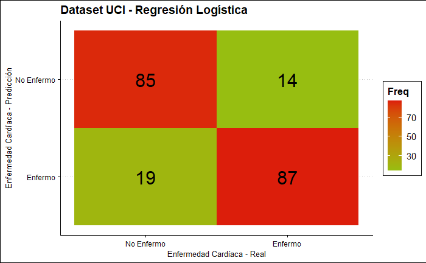

```r
ggplot(data = t.df, aes(x = Var2, y = pred, label=Freq)) +
geom_tile(aes(fill = Freq)) +
scale_fill_gradient(low="#97BE11",high="#DC1E0B") +
theme_clean() +
xlab("Enfermedad Cardíaca - Real") +
ylab("Enfermedad Cardíaca - Predicción") +
geom_text(size=8) +
ggtitle("Dataset UCI - Regresión Logística")
ggsave("UCI-RL-cf-matrix.png")
```

Lista la regresión logística. Falta la red neuronal.

```r
fitControl <- trainControl(method = "repeatedcv",
                            number = 10,
                            repeats = 10,
                            classProbs = TRUE,
                            summaryFunction = twoClassSummary)

gbm.ada.1 <- caret::train(target ~ .,
                          data = TrainingSet ,
                          method = "nnet",
                          trControl = fitControl,
                          metric="ROC")
```

```r
gbm.ada.1
```

```
Neural Network

820 samples
  5 predictor
  2 classes: 'Enfermo', 'No.Enfermo'

No pre-processing
Resampling: Cross-Validated (10 fold, repeated 10 times)
Summary of sample sizes: 739, 738, 739, 737, 738, 738, ...
Resampling results across tuning parameters:

  size  decay  ROC        Sens       Spec
  1     0e+00  0.8718317  0.8315061  0.7938205
  1     1e-04  0.8750306  0.8325637  0.7961154
  1     1e-01  0.8872436  0.8798117  0.7832564
  3     0e+00  0.9155543  0.8729457  0.7959808
  3     1e-04  0.9163783  0.8779679  0.7870897
  3     1e-01  0.9221377  0.8903378  0.8036923
  5     0e+00  0.9413594  0.8931783  0.8324615
  5     1e-04  0.9397150  0.8880509  0.8283718
  5     1e-01  0.9343740  0.8858749  0.8255962

ROC was used to select the optimal model using the largest value.
The final values used for the model were size = 5 and decay = 0.
```

```r
varImp(gbm.ada.1)
```

```
nnet variable importance
```

|  | Overall |
| --- | --- |
| ca | 100.00000 |
| cpDolor En Pecho Tipo 1 | 87.01322 |
| oldpeak | 49.11093 |
| cpDolor En Pecho Tipo 3 | 42.22306 |
| cpDolor En Pecho Tipo 2 | 41.36786 |
| sexMasculino | 41.16486 |
| exangAngina Inducida por Ejercicio | 0.00000 |

```r
pred <- predict(gbm.ada.1,ValidSet)
levels(pred)[2] <- "No Enfermo"
t<-table(pred, ValidSet$target)
t.df<-as.data.frame(t)
res<-caret::confusionMatrix(pred, ValidSet$target, positive = "Enfermo")
res
```

[output not shown]

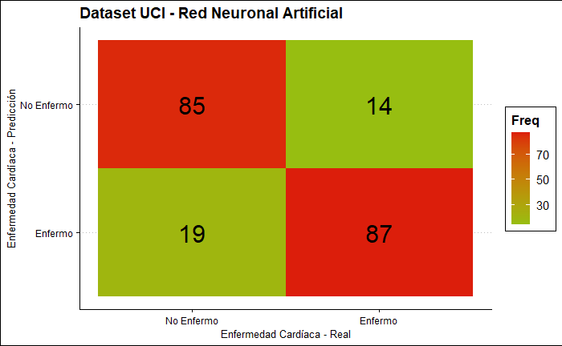

```r
ggplot(data = t.df, aes(x = Var2, y = pred, label=Freq)) +
geom_tile(aes(fill = Freq)) +
scale_fill_gradient(low="#97BE11",high="#DC1E0B") +
theme_clean() +
xlab("Enfermedad Cardíaca - Real") +
ylab("Enfermedad Cardíaca - Predicción") +
geom_text(size=8) +
ggtitle("Dataset UCI - Red Neuronal Artificial")
ggsave("UCI-RNA-cf-matrix.png")
```